# Introduction to responsesR package

Marko Lalovic

Last Updated: 2024-06-05

## Summary

The responsesR package provides an easy framework to simulate survey data commonly analyzed in applied social research, specifically Likert items. Likert items represent responses to survey questions or ratings, typically arranged on a psychometric scale defined by verbal labels with roughly equidistant categories symmetrically centered around a neutral midpoint. The most common form has five categories: Strongly disagree, Disagree, Neutral, Agree, and Strongly agree.

Users can specify latent variables by providing means, standard deviations, and optionally, skewness and correlations. The generated dataset represents responses to Likert scale questions, useful for various purposes such as validating theoretical findings obtained through techniques like Factor Analysis and Structural Equation Modeling. The package also allows for the estimation of parameters from existing survey data to replicate it more accurately.

## Statement of Need

In social sciences, variables of interest are often conceptualized as latent variables—hidden continuous variables that are measured through Likert scale questions, see Figure 1.

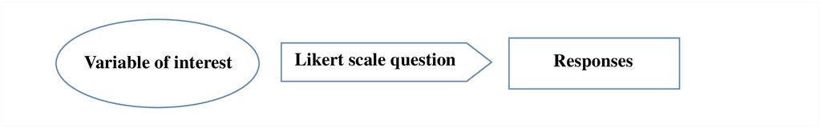

Figure 1: Flow diagram of the survey process.

Researchers frequently aim to uncover the connections between these latent variables using diverse statistical techniques. Having access to an effective algorithm to generate Likert items from hypothetical latent variables is essential for comparative analysis through simulation (Boari and Ruscone 2015).

Simulating Likert item responses often begins by selecting a continuous distribution, which is then transformed into a discrete probability distribution using a method called discretization. This process is illustrated in Figure 2.

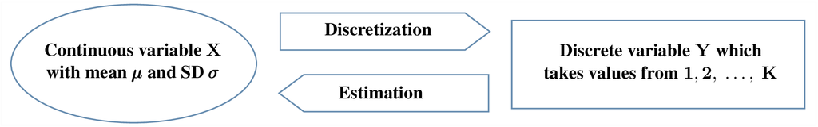

Figure 2: Flow diagram of the simulation process.

Unsupervised discretization, which subdivides the continuous range into intervals, is common (Wu and Leung 2017) but may yield suboptimal results, especially for non-uniform distributions (Catlett 1991). Furthermore, in many simulation studies, e.g.: (Velicer, Eaton, and Fava 2000), (Cho, Li, and Bandalos 2009), the latent distribution is often assumed to follow a normal distribution. However, this assumption is primarily for statistical convenience.

The responsesR package addresses these issues by implementing a supervised discretization approach using Lloyd’s algorithm. This ensures that simulated Likert items closely mirror the chosen continuous distributions, minimizing distortion and bias. The package also allows for the reconstruction of latent distributions from discrete data and handles non-normal latent distributions, enabling the generation of skewed responses.

## Dependency Statement

To maintain a lightweight package, responsesR only imports (Genz et al. 2020), along with the standard R packages stats and graphics, which are typically included in R releases. An additional suggested dependency is the package sn (Azzalini 2023), necessary only for generating random responses from correlated Likert items with multivariate skew normal latent distribution. However, the package prompts the user to install this dependency during interactive sessions.

## Related Software

There are alternative approaches for simulating Likert item responses. One approach is to define a discrete probability distribution and sample from it. This can be done using the `sample` function in R or the `likert` function from package wakefield (Rinker 2018). Another approach involves specifying the means, standard deviations, and correlations among the Likert items, using packages such as LikertMakeR (Winzar 2022) or SimCorMultRes (Touloumis 2016) to generate correlated multinomial responses. Alternatively, one can define a data generating process. For example (Arnulf, Larsen, and Martinsen 2018) is based on the semantic theory of survey responses. For those acquainted with item response theory, the mirt package (Chalmers 2012) enables users to input discrimination and difficulty parameters for choosing each response category.

## Simulation Process

Consider the following model, detailed in (Boari and Ruscone 2015). Let $X$ denote the continuous variable of interest, measured using Likert scale question with $K$ response categories. The observed discrete variable $Y$, representing possible responses, is defined as follows
$$Y = k, \quad \text{ if } \ \ \tau_{k - 1} < X \leq \tau_{k}
\quad \text{ for } \ \ k = 1, \dots, K$$
where $\tau_{k}$, $k = 0, \dots, K$ are thresholds defined in the domain of $X$ such that
$$-\infty = \tau_{0} < \tau_{1} < \dots < \tau_{K - 1} <
\tau_{K} = \infty.$$
The thresholds dictate the transformation of density $f_{X}$ of $X$ into a discrete probability distribution
$$\begin{equation*}
\text{Pr}(Y = k) = \int_{\tau_{k - 1}}^{\tau_{k}} f_{X}(x) \, dx
\quad \text{ for } \ \ k = 1, \dots, K.
\label{eq: probability_distribution}
\end{equation*}$$

To derive the thresholds, let $X_{1}$ be a random variable with mean 0 and standard deviation 1, representing the opinion or agreement of a neutral population. To transform $X_{1}$ into a discrete random variable $Y_{1}$ with as little distortion as possible, define the distortion as mean-squared error
$$\text{MSE} = \sum_{k = 1}^{K} \int_{\tau_{k - 1}}^{\tau_{k}}
f_{X_{1}}(x) \left( x - r_{k} \right)^{2} \, dx.$$
Here, $r_{k}$, $k = 1, \dots, K$, are representatives of intervals $(\tau_{k - 1}, \tau_{k}), k = 0, \dots, K$ that divide the domain of $X_{1}$. Quantization, achieved through Lloyd’s algorithm, finds optimal thresholds $\tau_{k}$ minimizing the mean-squared error. Although optimal representatives $r_{k}$ are found, they are not used since $Y_{1}$ takes values from $1$ to $K$.

Next, let $X_{2}$ be a random variable following the same distribution as $X_{1}$ but with different mean $\mu$ and standard deviation $\sigma$, representing the opinion or agreement of another population. The same thresholds $\tau_{k}$ are employed to compute the discrete probability distribution of random variable $Y_{2}$. Since $X_{1}$ and $X_{2}$ are measured using the same Likert scale question with $K$ response categories. In other words, the same categories $1, \dots, K$ are available to this second population.

This simulation process is visually depicted in Figures 3 and 4. These figures show the densities of normally distributed $X_{1}$ and $X_{2}$ in Figure 3A and skew normally distributed $X_{1}$ and $X_{2}$ with skewness $\gamma_{1} = - 0.6$ in Figure 4A. Corresponding discrete probability distributions of $Y_{1}$ and $Y_{2}$ with $K=5$ categories are presented in Figures 3B and 4B.

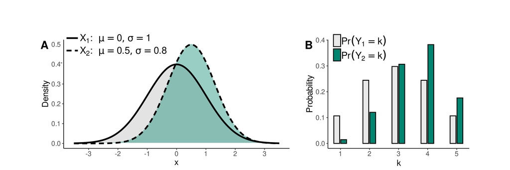

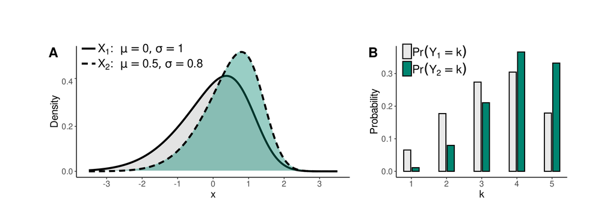

Figure 4: Relationship between skew normal $X$ with $\gamma_{1} = -0.6$, and responses $Y$.

Note that there are some disadvantages to measuring distortion only in a mean-squared sense. For example, we could make use of the fact that humans are more sensitive to some kinds of error than other, and for example permit larger errors when $|x|$ is large than when it is small.

To generate random responses from correlated Likert items, we first select the location vector, marginal skewness, and correlations between the latent variables. Then, draw a random sample from the multivariate normal or skew normal distribution with the appropriate location vector and covariance matrix. Lastly, discretize the sample using optimal thresholds $\tau_{k}$. Figure 5 illustrates this process for the case of 2 Likert items with 5 response categories, normal latent variables with means 0 and standard deviations 1, and a correlation of 0.7 between the variables.

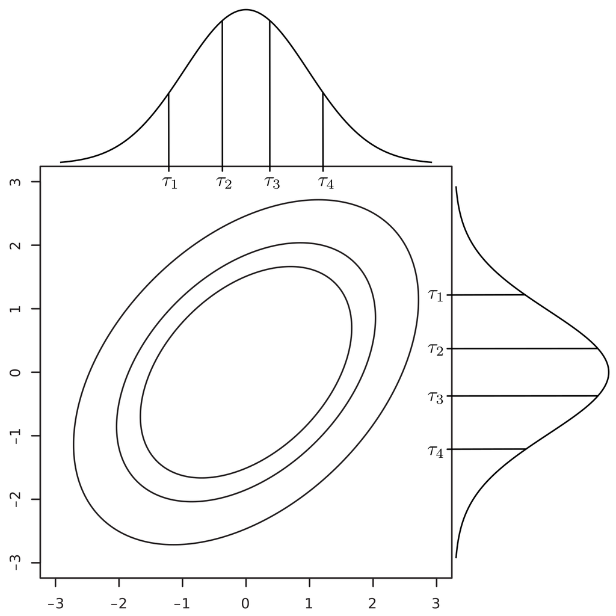

Figure 5: Normal bivariate and marginal latent distributions with a correlation of $0.7$ and optimal thresholds $\tau_1, \dots, \tau_{4}$.

## References

Arnulf, Jan Ketil, Kai R. Larsen, and Øyvind L. Martinsen. 2018. “Respondent Robotics: Simulating Responses to Likert-Scale Survey Items.” *Sage Open* 8 (1): 2158244018764803. https://doi.org/10.1177/2158244018764803.

Azzalini, Azzalini A. 2023. “Sn: The Skew-Normal and Related Distributions Such as the Skew-$t$.” Universita degli Studi di Padova, Italia. https://cran.r-project.org/package=sn.

Boari, Giuseppe, and Marta Nai Ruscone. 2015. “A Procedure Simulating Likert Scale Item Responses.” *Electronic Journal of Applied Statistical Analysis* 8 (3). http://siba-ese.unisalento.it/index.php/ejasa/article/view/14747.

Catlett, J. 1991. “On Changing Continuous Attributes into Ordered Discrete Attributes.” In *Proceedings of the 5th European Conference on European Working Session on Learning*, 164–78. EWSL’91. Berlin, Heidelberg: Springer-Verlag. https://doi.org/10.1007/BFb0017012.

Chalmers, R. Philip. 2012. “mirt: A Multidimensional Item Response Theory Package for the R Environment.” *Journal of Statistical Software* 48 (6): 1–29. https://doi.org/10.18637/jss.v048.i06.

Cho, Sun-Joo, Feiming Li, and Deborah Bandalos. 2009. “Accuracy of the Parallel Analysis Procedure with Polychoric Correlations.” *Educational and Psychological Measurement* 69 (5): 748–59. https://doi.org/10.1177/0013164409332229.

Genz, Alan, Frank Bretz, Tetsuhisa Miwa, Xuefei Mi, Friedrich Leisch, Fabian Scheipl, and Torsten Hothorn. 2020. “Mvtnorm: Multivariate Normal and t Distributions.” https://cran.r-project.org/package=mvtnorm.

Rinker, Tyler W. 2018. “Wakefield: Generate Random Data.” Buffalo, New York. https://github.com/trinker/wakefield.

Touloumis, Anestis. 2016. “Simulating Correlated Binary and Multinomial Responses Under Marginal Model Specification: The SimCorMultRes Package.” *The R Journal* 8 (2): 79–91. https://journal.r-project.org/archive/2016/RJ-2016-034/index.html.

Velicer, Wayne F, Cheryl A Eaton, and Joseph L Fava. 2000. “Construct Explication Through Factor or Component Analysis: A Review and Evaluation of Alternative Procedures for Determining the Number of Factors or Components.” *Problems and Solutions in Human Assessment: Honoring Douglas N. Jackson at Seventy*, 41–71.

Winzar, Hume. 2022. “LikertMakeR: Synthesise and Correlate Rating-Scale Data with Predefined First & Second Moments.” *The Comprehensive R Archive Network (CRAN)*. https://CRAN.R-project.org/package=LikertMakeR.

Wu, Huiping, and Shing-On Leung. 2017. “Can Likert Scales Be Treated as Interval Scales?—a Simulation Study.” *Journal of Social Service Research* 43 (4): 527–32. https://doi.org/10.1080/01488376.2017.1329775.